# Cómo mentir con datos

y cómo darte cuenta

Autor/a

Afiliación

Manuel Fernández San Martín

Laboratorio de Métodos Cuantitativos · FCE-UBA

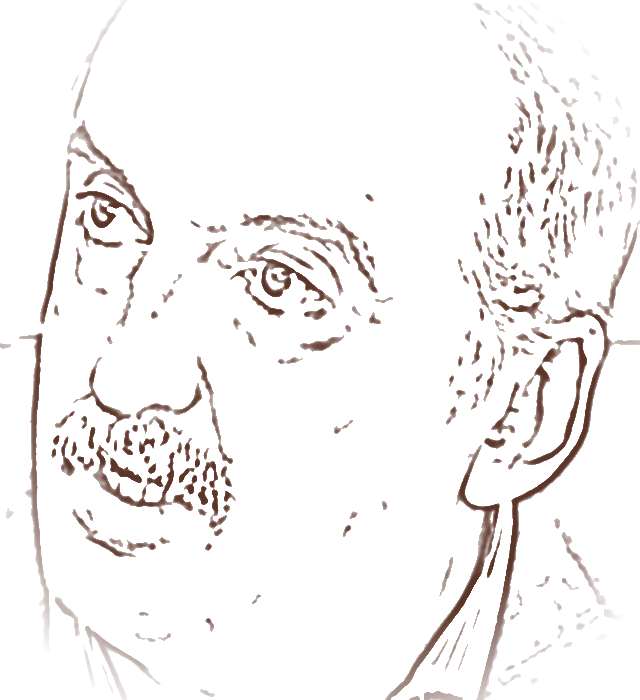

**Cómo usar esta página.** Es la clase entera: la podés leer a tu ritmo o proyectarla. Abajo a la derecha está el botón **🎤 Modo charla**, que la convierte en diapositivas: cada una trae todo lo de ese momento, por ejemplo el gráfico junto con la pregunta sobre ese gráfico. Se avanza con las flechas ← → (o con un control remoto) y la flecha → también destapa las respuestas. Las preguntas tienen la respuesta tapada: jugate antes de tocar **Revelar**. Todo funciona sin internet.

## Prólogo: los números no mienten… ¿o no?

Dos noticieros muestran el mismo día la inflación mensual del INDEC. Miren los títulos.

[figure not shown]

¿Cuál de los dos titulares dice la verdad?

- El de la izquierda
- El de la derecha
- Los dos
- Ninguno

**Los dos.** Los números son del INDEC y los gráficos están bien hechos. Lo único que cambia es qué meses eligió mostrar cada noticiero. Con los mismos datos se pueden contar historias opuestas sin inventar un solo número, y de eso se trata esta clase.

Hoy vamos a aprender a mentir con datos. Vamos a armar gráficos y números tramposos a propósito, para entender cómo funcionan y darnos cuenta **cuando nos lo hacen a nosotros**.

Vamos a seguir el camino de un número. Primero alguien *elige* qué medir, a quién preguntarle y qué período mirar; después *calcula* un resumen, y al final lo *dibuja*. Se puede hacer trampa en cualquiera de esos pasos, y las de los primeros son las más difíciles de ver. Vamos en orden, desde que nace el dato hasta que llega al titular.

Acto I

#### Lo que se elige

Qué se mide, a quién se le pregunta, qué período se muestra, qué se premia.

Acto II

#### Lo que se calcula

Promedios, porcentajes, probabilidades, correlaciones.

Acto III

#### Lo que se ve

Ejes, tortas, dibujos, mapas.

El cuarteto de Anscombe (1973)

Mismos números, **cuatro** historias.

Son cuatro conjuntos de 11 puntos con la misma media, la misma varianza, la misma correlación (0,82) y la misma recta de regresión. Antes de destaparlos: ¿cómo se imaginan los cuatro gráficos?

Después tocá I, II, III y IV, y arrastrá un punto para ver cómo cambian la recta y la consola.

Que pase alguien al frente. En el conjunto I, ¿hasta cuánto puede bajar el R² moviendo **un solo punto**? ¿Y subirlo?

Conjunto de datos

**Ver la consola**

*Anscombe (1973):* cuatro conjuntos con la misma media, varianza, correlación y recta de regresión. Arrastrá un punto y mirá la consola.

Las medias, las varianzas y la correlación de los cuatro conjuntos salen con pocas líneas de pandas. Copialo en Colab y probalo:

```python
import pandas as pd

x = [10, 8, 13, 9, 11, 14, 6, 4, 12, 7, 5]
datos = {
    "I":   (x, [8.04, 6.95, 7.58, 8.81, 8.33, 9.96, 7.24, 4.26, 10.84, 4.82, 5.68]),
    "II":  (x, [9.14, 8.14, 8.74, 8.77, 9.26, 8.10, 6.13, 3.10, 9.13, 7.26, 4.74]),
    "III": (x, [7.46, 6.77, 12.74, 7.11, 7.81, 8.84, 6.08, 5.39, 8.15, 6.42, 5.73]),
    "IV":  ([8] * 7 + [19] + [8] * 3, [6.58, 5.76, 7.71, 8.84, 8.47, 7.04, 5.25, 12.50, 5.56, 7.91, 6.89]),
}
anscombe = pd.concat([pd.DataFrame({"conjunto": k, "x": xs, "y": ys}) for k, (xs, ys) in datos.items()])

g = anscombe.groupby("conjunto")
g.agg(media_x=("x", "mean"), media_y=("y", "mean"), var_x=("x", "var"), var_y=("y", "var")).round(2)
g.apply(lambda d: d.x.corr(d.y)).round(3)       # las cuatro dan 0,816
```

**Pedí ver los datos, no solo el resumen.** Un promedio, una correlación o una recta comprimen todo en un número y se pierde la forma de los datos. Antes de creerle a un resumen, graficalo.

# Acto I · Mentir con datos

Acto I · Lo que se elige

Arrancamos por el nacimiento del dato: qué se cuenta como qué, a quién se le pregunta, qué período se muestra y qué pasa cuando un número se vuelve meta. Acá el gráfico y las cuentas pueden estar perfectos, porque la trampa se hizo antes, y por eso cuesta tanto verla.

La pyme de esta clase · inventada Dulce Dato S.R.L.

Una fábrica de alfajores de Lanús. Son 24 personas: 22 empleados, el gerente comercial y Marta, la dueña. Venden unos 400 mil alfajores por mes a kioscos, almacenes y algunos supermercados, y tienen tienda online.

Marta toma decisiones con números todos los días. A veces se los presentan bien y a veces no, y otras veces es ella la que quiere convencer a alguien (al banco, a un cliente, a sus empleados). La vamos a ver de los dos lados.

## 1 · ¿Qué estás midiendo?

La reunión de los lunes en Dulce Dato · inventada Tenemos 4.800 clientes

Marta le pregunta al gerente comercial cuántos clientes tiene la empresa. El gerente cobra un bono según el tamaño de su cartera.

¿Cuántos clientes tiene Dulce Dato?

- 4.800
- 1.240
- 610
- Depende de qué cuente como “cliente”

**Depende de qué cuente como “cliente”.** Los 4.800 son todos los que compraron *alguna vez* desde que abrió la fábrica, en 2014. Los que compraron en el último año son 1.240, y en el último mes, 610. Los tres números son ciertos y salen de la misma planilla. El gerente, que cobra según el tamaño de su cartera, eligió la definición que más le convenía.

### El truco

Antes de calcular nada, alguien decide **qué cuenta como qué**. “Cliente”, “venta”, “empleado”, “pobre”, “desocupado”: cada palabra esconde una definición, y moviéndola un poco el número cambia muchísimo. ¿Una venta es cuando se factura, cuando se entrega o cuando se cobra? ¿El que trabaja por agencia cuenta en la dotación? ¿El kiosco que compró una sola vez, hace cinco años, sigue siendo cliente? Casi nunca hay un número falso: la definición está en la letra chica, y casi nadie la lee.

Con pandas, la definición es un parámetro más: los mismos datos dan números distintos.

```python
import pandas as pd

compras = pd.DataFrame({
    "cliente": ["Kiosco Ana", "Almacén Lito", "Kiosco Ana", "Maxikiosco 24", "Almacén Lito", "Kiosco El Pibe"],
    "fecha": pd.to_datetime(["2026-09-28", "2026-09-10", "2025-12-01", "2025-11-15", "2024-03-02", "2019-07-19"]),
})
hoy = pd.Timestamp("2026-09-30")
ultima = compras.groupby("cliente").fecha.max()

for definicion, dias in [("compraron en el último mes", 30), ("compraron en el último año", 365), ("compraron alguna vez", None)]:
    activos = ultima if dias is None else ultima[hoy - ultima <= pd.Timedelta(days=dias)]
    print(f"Clientes que {definicion}: {len(activos)}")
```

**1**

La última compra de cada cliente.

**2**

Cambiar `dias` es cambiar la definición de “cliente”. Los datos son siempre los mismos.

```
Clientes que compraron en el último mes: 2
Clientes que compraron en el último año: 3
Clientes que compraron alguna vez: 4
```

En economía pasa lo mismo con la pobreza, el desempleo, la informalidad o la inflación. Cada una tiene una definición técnica que no siempre coincide con la del habla cotidiana, y que a veces cambia entre países o entre años.

Una persona trabajó **una hora** la semana pasada, cortando el pasto de un vecino por plata. Para el INDEC, ¿está desocupada?

- Sí: una hora no es un trabajo
- No: cuenta como ocupada
- Depende de si busca otro trabajo

**No: cuenta como ocupada.** Siguiendo las normas internacionales (OIT), la Encuesta Permanente de Hogares considera ocupado a quien trabajó al menos una hora en la semana de referencia. Si quiere trabajar más horas, es un ocupado *subocupado*. Y quien quiere trabajar pero no salió a buscar tampoco es desocupado, sino *inactivo*. Las reglas no son tramposas, pero hay que conocerlas antes de comparar números.

### Hacelo vos

Son 100 personas inventadas, con proporciones parecidas a las de la EPH. Según a quién cuentes como desocupado, la tasa va de 7% a más de 20%. Lo correcto es usar la definición estándar y, si querés mostrar otra cosa, mostrarla aparte y con su nombre (la tasa de subocupación, o la de desocupación más desalentados).

### ⭐ Cuando el que miente es el que mide

¿Cuánta inflación hubo en la Argentina en 2010?

- 10,9%, como informó el INDEC
- Alrededor de 25%
- No lo sabemos con certeza

**No lo sabemos con certeza.** El INDEC informó 10,9%. Pero en enero de 2007, con el secretario de Comercio Interior a la cabeza (Guillermo Moreno, que anda escondido en la portada), el gobierno intervino el organismo, desplazó a la técnica a cargo del índice de precios, y el índice dejó de ser creíble. Las consultoras privadas y varias provincias medían más del doble, y un estudio con precios de supermercados online (Cavallo, 2013) encontró que entre 2007 y 2011 la inflación fue casi el triple de la oficial. Hasta el redondeo era raro: desde mediados de 2008, durante 33 meses seguidos, la inflación mensual oficial nunca redondeó para arriba. Es como sacar 33 caras seguidas con una moneda, algo que pasa 1 vez cada 8.590 millones ([lo calculó FIEL en una nota de 2011](https://www.fiel.org/publicaciones/ArticulosDiario/Perfil%20AV%205-2011.pdf)). En 2016 se declaró la emergencia estadística y el propio INDEC advirtió que las series publicadas desde 2007 debían tomarse con reservas.

Es el caso más grave, porque el dato queda arruinado desde el origen y ningún gráfico lo arregla después. Por eso importa tanto que las estadísticas públicas sean independientes y publiquen sus métodos.

**Leé la definición.** Antes de comparar números, fijate qué cuenta como qué y quién lo produjo.

## 2 · ¿A quién le preguntaste?

Encuesta en el Instagram de Dulce Dato · inventada Al 71% le encanta el nuevo alfajor de pistacho, según una encuesta con más de 1.500 respuestas

Marta tiene que decidir si lo fabrica para todos los kioscos o si lo deja como prueba.

¿Lo lanzarían en todos los kioscos?

- Sí: 1.500 respuestas es un montón
- Sí, si el margen de error es chico
- Todavía no: importa más quién contestó que cuántos

**Todavía no.** Contestaron los que siguen a la marca y además tuvieron ganas de contestar, o sea, los fans, que no se parecen al cliente de un kiosco cualquiera. Con más respuestas del mismo tipo no se arregla. En 1936 la revista *Literary Digest* juntó más de dos millones de respuestas por correo y pronosticó que Roosevelt perdía; ganó por paliza. George Gallup acertó con una muestra mucho más chica pero bien elegida.

### El truco

Casi nunca se mide a toda la población: se toma una **muestra**. Ahí se puede mentir (o equivocarse) de dos formas:

- **Muestras sesgadas.** Encuestas online, gente que se ofrece para un estudio, “le pregunté a los vendedores”, “le pregunté a mis amigos”. Lo mismo hacemos todos cuando generalizamos a partir de la gente que conocemos.
- **Muestras chiquitas.** “El 66% de los hombres dice que su prioridad es la plata” (preguntaron a 15). Un libro clásico cuenta que “un tercio de las mujeres que fueron a la universidad se casó con un profesor”: eran tres mujeres, y una se casó con un profesor.

### Hacelo vos

Hagan clic varias veces en cada botón. ¿Cuál tiene más respuestas? ¿Cuál le erra más? ¿Por qué la de Instagram le erra siempre para el mismo lado?

### Los que no volvieron

Los aviones que vuelven de combate llegan con agujeros de bala como en el dibujo.

[figure not shown]

Hay que agregar blindaje, pero pesa: solo se puede reforzar una parte. ¿Dónde lo ponen?

- En las alas, el fuselaje y la cola, donde hay más agujeros
- En los motores y la cabina, donde no hay agujeros

**En los motores y la cabina.** El estadístico Abraham Wald se dio cuenta de que la muestra solo tenía los aviones *que volvieron*. Los que recibían balazos en el motor o en la cabina no volvían a contarlo. Los agujeros muestran dónde un avión puede recibir un tiro y volver igual. Se llama **sesgo de supervivencia**, y aparece también en la encuesta de satisfacción de una empresa (los clientes que se fueron enojados no la contestan) o en los fondos de inversión que “siempre ganaron” (los que perdieron cerraron y ya no están en la lista).

```python
import numpy as np

rng = np.random.default_rng(1)
le_encanta = rng.random(10_000) < 0.40                 # 10.000 clientes: al 40% le encanta el pistacho (la verdad)

# Instagram: contesta el 30% de los fans y el 8% de los que no
contesta = rng.random(10_000) < np.where(le_encanta, 0.30, 0.08)
print(f"Instagram: {le_encanta[contesta].mean():.0%} dice que le encanta, con {contesta.sum()} respuestas")

aleatoria = rng.choice(le_encanta, size=400, replace=False)
print(f"Aleatoria: {aleatoria.mean():.0%} dice que le encanta, con 400 respuestas")
```

**1**

Quién contesta depende de lo que piensa: la muestra está sesgada, por más grande que sea.

**2**

Una muestra aleatoria chica le pega mucho más cerca.

```
Instagram: 70% dice que le encanta, con 1734 respuestas
Aleatoria: 40% dice que le encanta, con 400 respuestas
```

**Preguntá a quién le preguntaron.** Cuántos eran, cómo se eligieron y quiénes no aparecen (los que no contestaron, los que no sobrevivieron). Una encuesta enorme pero mal elegida le erra igual.

## 3 · Elegí la ventana, elegí la historia

### El truco

¿Se acuerdan de los dos noticieros del principio? El que dijo que la inflación “no para de subir” mostró de mayo de 2025 a marzo de 2026, que son 11 meses, una cantidad rara. Si arrancaba un mes antes ya no se veía una subida constante, y desde diciembre de 2023 se veía una caída enorme.

Esto se llama **cherry picking**: quedarse con la parte de los datos que le sirve a tu postura y dejar afuera la que la contradice. Se hace eligiendo dónde empieza y dónde termina el gráfico, qué países se comparan, qué años o qué mes base.

En una empresa se ve seguido. El gerente muestra las ventas “desde que llegó”, la dueña le lleva al banco solo los meses buenos y el proveedor compara su precio con el de la competencia justo el mes en que el otro estaba más caro.

### Cortar la hoja

Entrevista en C5N, agosto de 2020 El cuadro éste deberíamos cortarlo acá

Alberto Fernández habla del acuerdo con los bonistas. Le acercan un gráfico con los pagos de deuda de cada año, antes y después del acuerdo, y antes de mostrarlo dobla la hoja.

[figure not shown]

¿Qué quedó del otro lado del doblez?

- Nada importante: años muy lejanos
- Los años en los que, con el acuerdo, se paga más que antes
- La fuente del gráfico

**Los años en los que, con el acuerdo, se paga más.** El gráfico completo está en la diapositiva que sigue.

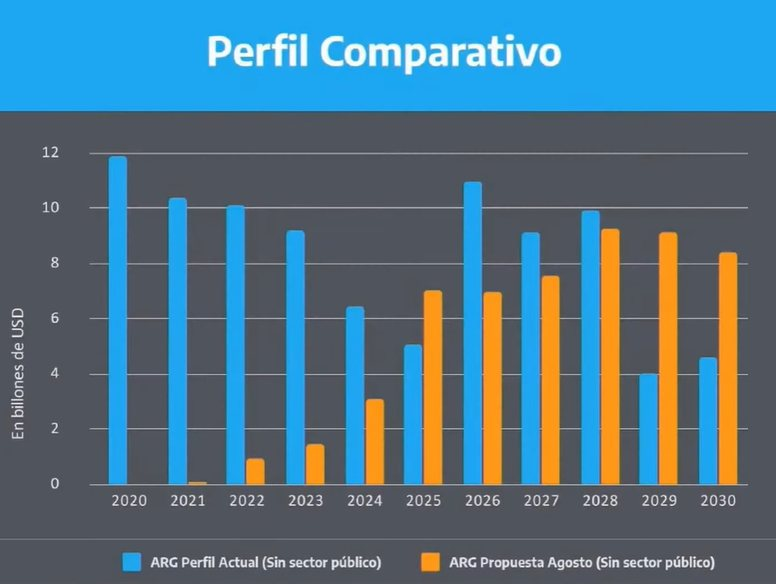

**Del otro lado del doblez.** El gráfico completo, que el ministro Guzmán había mostrado ese mismo día, llegaba hasta 2030. Hasta 2024 los pagos con el acuerdo (naranja) son mucho menores que los de antes (celeste), pero en 2025, 2029 y 2030 son mayores, porque el acuerdo estiró los plazos.

El ahorro existió: los especialistas lo calcularon en más de 30.000 millones de dólares. Pero mirando solo los primeros años parece mucho más grande.

### Cambiar de serie

Otra forma de elegir la ventana es elegir **qué serie** mirar, después de ver cuál conviene. El INDEC publica la actividad económica (el EMAE) en dos versiones: la serie desestacionalizada y la tendencia-ciclo, que es más suave.

Luis Caputo, sobre el EMAE de marzo de 2026

«El nivel de actividad económica alcanzó un nuevo máximo histórico en marzo. […] Registró un crecimiento de 3,5% mensual en la **serie desestacionalizada**.»

Luis Caputo, cuando la misma serie cayó 2,9% en julio de 2026

«Si se mira el **EMAE desestacionalizado**, claramente está dando un nivel de volatilidad que no refleja la realidad.»

Y Milei, en esos días: «Nosotros nos enfocamos en el indicador tendencia a ciclo». Con la pobreza pasó algo parecido: en el primer semestre de 2026 subió 4,1 puntos contra el semestre anterior, y el tuit oficial la comparó con el primer semestre de 2024.

### Hacelo vos

**Dos equipos, la misma serie.** El equipo A tiene que encontrar la ventana más honesta posible en la que “la inflación se disparó”. El equipo B, una en la que “se desplomó”. Gana el titular más dramático que el otro equipo no pueda desmentir *sin cambiar la ventana*.

Conviene no quedarse con un solo gráfico de un solo medio, por más prolijo que sea: mirar la serie completa, comparar fuentes y, cuando se puede, ir a la fuente de los datos. El INDEC publica la serie entera y es gratis.

```python
# ¿En cuántas ventanas de al menos 6 meses la inflación "sube" y en cuántas "baja"?
url = "https://apis.datos.gob.ar/series/api/series/?ids=148.3_INIVELNAL_DICI_M_26&format=csv&limit=5000"
nivel = pd.read_csv(url, index_col=0, parse_dates=True,
                    storage_options={"User-Agent": "Mozilla/5.0"}).iloc[:, 0]
inflacion = nivel.pct_change().dropna() * 100                   # variación mensual
sube = baja = 0
for i in range(len(inflacion)):
    for j in range(i + 6, len(inflacion)):
        if inflacion.iloc[j] > inflacion.iloc[i]:
            sube += 1
        else:
            baja += 1
print(f"Ventanas donde 'sube': {sube} · donde 'baja': {baja}")
```

**1**

La API de datos.gob.ar rechaza el “User-Agent” que manda Python por defecto (error 403). Con mandar cualquier otro, alcanza.

**2**

Todas las ventanas posibles de 6 meses o más: cada una es un titular posible.

**3**

Hay miles de ventanas que cuentan cada historia, y en todas los números son ciertos.

```
Ventanas donde 'sube': 3657 · donde 'baja': 2448
```

**Preguntá por qué empieza y termina ahí.** Pedí la serie completa. Si la conclusión se da vuelta cuando corrés la ventana un par de meses, desconfiá.

## 4 · Cuando la medida se vuelve meta

Pedro Rosemblat le pregunta a Luquitas Rodríguez cómo se mide si lo que hacen “pega”.

[video not shown]

Las agencias cuentan menciones y vistas, y con esos números se ordena la industria. ¿Qué pasa cuando todos empiezan a trabajar para esos números?

Marta, en la reunión de octubre de 2025 · inventado Quiero vender más

Mirando los números del último año, Marta ve que los meses en que aparecen más clientes nuevos son también los meses en que más se vende. Tiene sentido: cada kiosco nuevo es alguien más comprando alfajores.

Entonces decide que, desde octubre, el gerente comercial va a cobrar un bono por cada cliente nuevo que consiga. Un año después, el gerente le muestra su tablero.

El tablero del gerente comercial · inventado Récord: 198 clientes nuevos en septiembre

[figure not shown]

¿Le renovarías el bono al gerente?

- Sí, se lo ganó: es un récord
- Depende: hay que ver qué pasó con las ventas
- No: los bonos nunca funcionan

**Hay que ver las ventas, y bajaron.** El gerente aprendió a fabricar clientes nuevos: abre una cuenta distinta para cada sucursal de un mismo supermercado, regala una caja a kioscos que compran una vez y no vuelven, y pasa más tiempo buscando clientes chiquitos que atendiendo a los grandes. Contra septiembre del año pasado, los clientes nuevos se multiplicaron por 4 y las ventas cayeron 16%.

### El truco

Se conoce como **ley de Goodhart**, por Charles Goodhart, economista del Banco de Inglaterra, que la planteó en 1975: cualquier regularidad estadística tiende a desarmarse apenas se la usa para controlar algo. La frase que se hizo famosa es de la antropóloga Marilyn Strathern: **cuando una medida se convierte en meta, deja de ser una buena medida.**

Antes del bono, los clientes nuevos eran un buen termómetro de Dulce Dato, porque subían cuando se vendía más. En cuanto Marta empezó a pagar por ese número, el gerente encontró cómo moverlo sin vender más. Tampoco tuvo que mentir; hizo lo que le convenía.

Otros ejemplos: el call center que mide cuánto duran las llamadas, donde los operadores aprenden a cortar rápido, o el viejo chiste de la fábrica soviética de clavos. Si la meta es en toneladas, fabrica un clavo gigante, y si es en unidades, millones de clavitos que no sirven.

### ⭐ El dinero que dejó de avisar

En el Reino Unido de los años 70, la cantidad de dinero en la economía y la inflación se movían bastante juntas. En 1980, para bajar la inflación, el gobierno de Margaret Thatcher le puso una meta a la cantidad de dinero. ¿Qué pasó?

- La cantidad de dinero creció dentro de la meta y la inflación bajó
- La cantidad de dinero se pasó de la meta y, aun así, la inflación bajó
- La cantidad de dinero cumplió la meta, pero la inflación siguió alta

**Se pasó de la meta y, aun así, la inflación bajó.** El agregado elegido (se llamaba £M3) tenía que crecer entre 7% y 11% en el primer año, y creció casi 20%. Bancos y ahorristas cambiaron cómo guardaban y prestaban la plata, y £M3 dejó de decir lo que decía antes. La inflación bajó de 18% en 1980 a menos de 5% en 1983, por otras razones: una recesión fuerte y tasas de interés altísimas. A mediados de la década, el gobierno abandonó la meta. Goodhart había hecho su advertencia pensando justamente en estos agregados de dinero.

La versión argentina la vimos en el módulo 1: en 2007, cuando el número de inflación se volvió una meta política, se intervino directamente al organismo que lo medía.

### Hacelo vos

¿Con qué peso del bono el tablero muestra el doble de clientes nuevos que un mes típico? Miren la correlación: ¿en qué momento los clientes nuevos dejan de avisar cómo van las ventas?

```python
import numpy as np
import pandas as pd

rng = np.random.default_rng(11)
meses = pd.date_range("2024-10-01", "2026-09-01", freq="MS")
frio = np.cos(2 * np.pi * (meses.month - 7) / 12)                  # en invierno se venden más alfajores
demanda = frio + np.convolve(rng.normal(0, 0.5, len(meses) + 2), np.ones(3) / 3, "valid")   # y algo de azar
datos = pd.DataFrame({"clientes": 42 + 9 * demanda + rng.normal(0, 2, len(meses)),
                      "ventas": 390 + 25 * demanda + rng.normal(0, 5, len(meses))}, index=meses)

con_bono = datos.index >= "2025-10-01"
meses_con_bono = np.cumsum(con_bono)                                # 1, 2, 3... desde que arranca el bono
datos["clientes"] += 0.6 * 22 * meses_con_bono
datos["ventas"] -= 0.6 * 7 * meses_con_bono

print("Correlación sin bono:", round(datos[~con_bono].corr().iloc[0, 1], 2))
print("Correlación con bono:", round(datos[con_bono].corr().iloc[0, 1], 2))
```

**1**

Clientes “fabricados”: cada mes con bono aparecen más cuentas que compran una vez.

**2**

Y las ventas bajan un poco: descuentos para enganchar clientes y menos tiempo para los grandes.

**3**

La relación entre las dos series, que era la razón para mirar los clientes nuevos, se da vuelta.

```
Correlación sin bono: 0.94
Correlación con bono: -0.38
```

**Preguntá quién cobra por ese número.** Cuando un indicador se usa para premiar o castigar, la gente aprende a moverlo. Mirá también lo que el indicador tenía que reflejar, y no te quedes con una sola medida.

# Acto II · Mentir con estadística

Acto II · Lo que se calcula

Ahora el dato ya está juntado y las cuentas están bien hechas. La trampa está en **qué número** se elige para resumir y en **contra qué** se lo compara.

## 5 · El promedio que nadie gana

Dulce Dato, paritaria de marzo · inventado Los sueldos no alcanzan

El delegado de los trabajadores le pide a Marta un aumento: dice que con lo que cobran no llegan a fin de mes. Marta no quiere dar más de lo que subieron los precios, y arma su respuesta con la planilla de sueldos de la empresa.

Reunión de Marta con el delegado de los trabajadores · inventada En esta empresa el sueldo promedio es de 2,1 millones. No se pueden quejar.

Marta hizo bien la cuenta: sumó los 24 sueldos de Dulce Dato y dividió por 24.

Si ordenás a las 24 personas de menor a mayor sueldo, ¿cuánto cobra la que queda en el medio?

**Unos $1.390.000**, un tercio menos que el “promedio”. De las 24 personas, 21 cobran menos que el promedio. Lo que lo tira para arriba es el sueldo del gerente comercial (4,5 millones) y, sobre todo, lo que retira Marta: 14 millones por mes. El valor del medio se llama **mediana**, y es lo que cobra un empleado típico de Dulce Dato.

### El truco

“Promedio” puede querer decir varias cosas. La **media** suma todo y divide. La **mediana** es el valor del medio. Cuando la distribución es asimétrica (sueldos, ingresos, patrimonios, precios de casas), unos pocos valores enormes tiran la media para arriba. “El sueldo promedio subió” puede ser cierto aunque a la mayoría no le haya cambiado nada, si la que se aumentó fue la dueña. Es el viejo chiste: si Messi entra a esta aula, en promedio somos todos millonarios.

En la Argentina, como en casi todo el mundo, la media del ingreso queda por encima de la mediana, así que al que quiere mostrar que “estamos bien” le conviene la media. Para saber qué le pasa a una persona típica hay que mirar la mediana.

### Hacelo vos

Cada barra es una persona de Dulce Dato. Mové lo que se paga Marta y mirá qué pasa con la media y con la mediana.

¿Cuánto se tiene que pagar Marta para que el “sueldo promedio” llegue a 3 millones? ¿Cuánto cambia la mediana mientras tanto?

```python
import numpy as np

sueldos = np.array([1.18, 1.20, 1.22, 1.24, 1.25, 1.26, 1.28, 1.30, 1.31, 1.33, 1.35, 1.38, 1.40, 1.45,  # operarios
                    1.42, 1.50, 1.62, 1.48, 1.55, 1.85, 1.95, 2.30,                                    # el resto del personal
                    4.50, 14.00])                                                                       # gerente y dueña
print(f"media: {sueldos.mean():.2f} | mediana: {np.median(sueldos):.2f}   (millones de pesos)")
print("cobran menos que la media:", (sueldos < sueldos.mean()).sum(), "de", len(sueldos))

sin_duenia = sueldos[:-1]
print(f"sin la dueña -> media: {sin_duenia.mean():.2f} | mediana: {np.median(sin_duenia):.2f}")
```

**1**

Con datos asimétricos, la mayoría queda por debajo de la media.

**2**

Un solo valor extremo mueve mucho la media y casi nada la mediana.

```
media: 2.10 | mediana: 1.39   (millones de pesos)
cobran menos que la media: 21 de 24
sin la dueña -> media: 1.58 | mediana: 1.38
```

**Preguntá qué promedio es.** Con datos asimétricos (sueldos, ingresos, patrimonio, precios), los de arriba tiran la media para arriba, y la mediana dice qué le pasa a la persona del medio.

## 6 · Porcentajes que asustan

### ¿Subió 5% o 100%?

Dos diarios, el mismo dato · inventado La deserción escolar subió 5% La deserción escolar se duplicó

En un país, el porcentaje de chicos que abandona la secundaria pasó de 5% a 10% en un año.

¿Cuánto subió la deserción?

- 5 puntos porcentuales
- 100%
- Las dos cosas, según cómo lo digas

**Las dos cosas son ciertas.** La tasa subió **5 puntos porcentuales**, de 5% a 10%, y la cantidad de chicos que abandona se duplicó, o sea que subió **100%**. Lo que está mal es decir “subió 5%”: confunde puntos con porcentaje y de paso lo hace sonar a poco. ¿Cuál de los dos titulares describe mejor lo que pasó? Discutámoslo.

### Relativo contra absoluto

Cuando la base es muy chiquita, el porcentaje asusta todavía más. Este caso es real.

Reino Unido, octubre de 1995 Advertencia oficial: los anticonceptivos de tercera generación duplican el riesgo de trombosis

Si estuvieras tomando esa píldora, ¿qué harías?

- La dejo ya
- Consulto al médico pero sigo tomándola
- Antes de decidir, pregunto: ¿el doble de cuánto?

**¿El doble de cuánto?** Con la píldora vieja, 1 de cada 7.000 mujeres tenía una trombosis. Con la nueva, 2 de cada 7.000. Es verdad que el riesgo se duplicó (+100%), pero el aumento absoluto fue de 1 caso cada 7.000 mujeres. Muchas dejaron la píldora de golpe. Se estima que al año siguiente hubo unos 13.000 abortos más en Inglaterra y Gales, y el embarazo tiene un riesgo de trombosis mayor que el de cualquier píldora.

“Duplica el riesgo”, “reduce a la mitad”, “+100%”: los **riesgos relativos** suenan enormes cuando el riesgo de base es chiquito. Para decidir hace falta el **riesgo absoluto**: cuántos casos cada 1.000 o cada 10.000 personas.

### Las cuentas de la pyme

En enero, las ventas de Dulce Dato cayeron 50%. En febrero subieron 50%. ¿Volvieron a donde estaban?

- Sí
- No: quedaron 25% abajo
- No: quedaron 25% arriba

**Quedaron 25% abajo.** Si vendían 100, bajaron a 50. Y el 50% de 50 es 25: subieron a 75. Cada porcentaje se calcula sobre una base distinta. Lo mismo con los márgenes: un alfajor que cuesta $1.000 y se vende a $1.500 deja un 50% **sobre el costo** (el *markup*) y un 33% **sobre el precio** (el margen). Si un proveedor te dice “te dejo un 50%”, preguntale sobre qué.

### ⭐ Nominal contra real

Titular inventado · datos reales del INDEC Los salarios registrados subieron 295% desde noviembre de 2023

¿Pueden comprar más cosas hoy que en noviembre de 2023 con su sueldo?

- Sí, muchas más
- Un poco más
- No se puede saber con ese dato

**Con ese dato, no se puede saber.** Hay que compararlo con cuánto subieron los precios. En el mismo período el IPC se multiplicó por 4,29 y el salario por 3,95. Descontada la inflación, el salario registrado de jul 2026 compra un 8% *menos* que el de noviembre de 2023.

Con inflación, cualquier cosa medida en pesos “sube”: salarios, ventas, recaudación, el precio de un alfajor. Un número **nominal** no dice mucho hasta que lo comparás con los precios; el que importa es el **real** (deflactado). Si las ventas de Dulce Dato crecieron 40% en pesos en un año en que los precios subieron 30%, en realidad crecieron menos de 8% (1,40 / 1,30 = 1,077).

**Tramposo**

```python
nominal = d_real.salarios / d_real.salarios.iloc[0] * 100
fig, ax = plt.subplots()
ax.plot(nominal.index, nominal)
ax.set_title("Salarios: ¡casi se cuadruplicaron!")
plt.show()
```

**1**

Pesos de cada mes: con 4 veces más precios, que el salario se multiplique por 4 no dice nada.

[figure not shown]

**Honesto**

```python
real = (d_real.salarios / d_real.ipc) / (d_real.salarios.iloc[0] / d_real.ipc.iloc[0]) * 100
fig, ax = plt.subplots()
ax.plot(real.index, real, color="C2")
ax.axhline(100, color="0.7", lw=1)
ax.set_title("Salario real (nov 2023 = 100)")
plt.show()
```

**1**

Salario dividido por el nivel de precios: cuántas “canastas” compra.

[figure not shown]

**Pedí la base.** “El doble” de 1 en 7.000 sigue siendo poquísimo: pedí el riesgo absoluto. Distinguí porcentaje de puntos porcentuales y preguntá sobre qué se calcula cada porcentaje. Y con inflación, cualquier monto en pesos tiene que venir deflactado.

## 7 · La máquina que acierta el 99%

La máquina nueva de Dulce Dato · inventada Nuestro detector de fallas acierta el 99%

Marta compró una máquina que revisa cada alfajor y descarta los fallados: rotos, mal bañados, sin dulce. Sale fallado 1 de cada 100. La máquina descarta al 99% de los fallados y deja pasar al 99% de los buenos. Un alfajor sale descartado.

¿Qué probabilidad hay de que esté fallado de verdad?

**50%.** Imaginá 1.000 alfajores. 10 están fallados y la máquina descarta a casi todos: 10 descartes justos. Pero de los 990 buenos, el 1% también se descarta: otros 10. De los 20 descartados, la mitad estaba bien. Cuando la falla es rara, hasta una máquina buenísima tira a la basura un montón de alfajores sanos.

### El truco

Confundir dos probabilidades que suenan parecidas:

- P(descartado | fallado): qué tan bien detecta la máquina. Es el 99% del folleto.
- P(fallado | descartado): lo que a Marta le importa.

Para pasar de una a la otra hace falta la **tasa base**: qué tan común es la falla antes de mirar ningún alfajor. Es el mismo problema de un test médico que “acierta el 99%” con una enfermedad rara, o de un sistema antifraude que bloquea compras con tarjeta. Olvidarse de ella se llama **falacia de la tasa base**.

En los tribunales se llama **falacia del fiscal**: confundir “qué chance hay de que un inocente coincida con la evidencia” con “qué chance hay de que este acusado sea inocente”. Con ese error, en 1999, en Inglaterra, condenaron a Sally Clark por la muerte de sus dos bebés con un “1 en 73 millones”. Fue liberada en 2003.

### Hacelo vos

Con la máquina al 99/99, ¿qué tan común tiene que ser la falla para que un alfajor descartado tenga 90% de chances de estar fallado?

```python
def prob_fallado_si_descarta(tasa_falla, detecta, deja_pasar):
    justos = tasa_falla * detecta
    falsas_alarmas = (1 - tasa_falla) * (1 - deja_pasar)
    return justos / (justos + falsas_alarmas)

for falla in [0.001, 0.01, 0.1, 0.3]:
    print(f"falla {falla:>5.1%}  ->  P(fallado | descartado) = {prob_fallado_si_descarta(falla, 0.99, 0.99):.1%}")
```

**1**

Alfajores fallados que la máquina descarta.

**2**

Alfajores buenos que descarta igual (falsas alarmas).

**3**

Teorema de Bayes: de todos los descartados, qué parte estaba fallada.

```
falla  0.1%  ->  P(fallado | descartado) = 9.0%
falla  1.0%  ->  P(fallado | descartado) = 50.0%
falla 10.0%  ->  P(fallado | descartado) = 91.7%
falla 30.0%  ->  P(fallado | descartado) = 97.7%
```

**Preguntá por la tasa base.** “Acierta el 99%” no dice nada sin saber cuán común es lo que se busca. Y no confundas P(evidencia | inocente) con P(inocente | evidencia).

## 8 · Juntos dicen una cosa, separados otra

Dulce Dato, fin de septiembre · inventado Un premio al mejor vendedor

Dulce Dato tiene dos vendedores, Diego y Laura, que visitan kioscos, almacenes y supermercados. Este mes Marta quiere premiar al que mejor vende, y le pide al gerente que los compare: qué parte de sus visitas terminan en una venta.

La planilla del gerente comercial · inventada Diego cierra el 63% de sus visitas y Laura, el 38%. El premio al mejor vendedor es para Diego.

¿Le darían el premio a Diego?

- Sí, está clarísimo
- No: es casualidad
- Depende de a qué clientes visitó cada uno

**Depende de a qué clientes visitó cada uno.** Si se separan por tipo de cliente, Laura cierra más ventas que Diego **en los tres**: en kioscos, en almacenes y en supermercados. ¿Cómo puede ser? A Diego le tocaron casi todos kioscos, donde vender es fácil. A Laura le tocaron los supermercados, donde cualquier vendedor cierra pocas ventas.

### El truco

Es la **paradoja de Simpson**: una tendencia que aparece en cada grupo se invierte (o desaparece) cuando juntás los grupos. Pasa cuando hay una tercera variable (acá, qué clientes le tocaron a cada uno) relacionada con las otras dos. El ejemplo clásico es el del ejercicio y el colesterol. Mirando a todos juntos, parece que el que hace más ejercicio tiene más colesterol; separando por edad, en cada grupo pasa lo contrario. La edad mueve las dos cosas: los más grandes hacen más ejercicio y también tienen más colesterol.

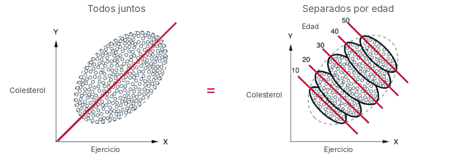

Un caso real: en el otoño de 1973, la Universidad de California en Berkeley admitió en el posgrado al 44% de los hombres y solo al 35% de las mujeres que se postularon. ¿Discriminaba? Un equipo de estadísticos (Bickel, Hammel y O’Connell, 1975) miró departamento por departamento: en la mayoría, las mujeres entraban en igual o **mayor** proporción que los hombres. Se postulaban más a los departamentos más difíciles, donde entraba poca gente de cualquier sexo.

### Hacelo vos

```python
import pandas as pd

visitas = pd.DataFrame({
    "cliente": ["Kioscos", "Almacenes", "Supermercados"],
    "diego_visitas": [120, 60, 20], "diego_ventas": [90, 33, 3],
    "laura_visitas": [20, 60, 120], "laura_ventas": [16, 36, 24],
})
total_diego = visitas.diego_ventas.sum() / visitas.diego_visitas.sum()
total_laura = visitas.laura_ventas.sum() / visitas.laura_visitas.sum()
print(f"Todo junto: Diego {total_diego:.0%}, Laura {total_laura:.0%}")

visitas["diego"] = visitas.diego_ventas / visitas.diego_visitas
visitas["laura"] = visitas.laura_ventas / visitas.laura_visitas
print(visitas[["cliente", "diego", "laura"]].round(2))
```

**1**

Todo junto: gana Diego.

**2**

Por tipo de cliente: Laura gana en los tres.

```
Todo junto: Diego 63%, Laura 38%
         cliente  diego  laura
0        Kioscos   0.75    0.8
1      Almacenes   0.55    0.6
2  Supermercados   0.15    0.2
```

**Pedí los datos por grupo.** Cuando un total compara grupos que son muy distintos por dentro, la conclusión puede darse vuelta al separarlos. Preguntá qué tercera variable puede estar mezclando todo.

## 9 · Correlación no es causalidad

Spurious Correlations, de Tyler Vigen (CC BY 4.0) Los goles de Messi con la Selección y la contaminación del aire en Gainesville, Florida

[figure not shown]

¿Cuánto da la correlación entre las dos series?

**r = 0,97.** Casi perfecta, y obviamente no hay ninguna relación entre las dos cosas. Son solo 7 años, y la “contaminación” son uno o dos días malos por año. Con tan pocos puntos, si cruzás miles de series siempre aparece alguna que coincide, y Vigen cruzó más de 25.000. (El gráfico, además, tiene dos ejes. A eso volvemos en el módulo 15.)

### El truco

Que dos cosas se muevan juntas no dice que una cause la otra. Hay al menos cuatro explicaciones alternativas:

1. **Una tercera causa.** En Dulce Dato, los meses en que más se gasta en publicidad son los meses en que más se vende. ¿La publicidad funciona? Puede ser. Pero Marta pauta más en invierno, que es cuando más alfajores se compran: el frío mueve las dos cosas.
2. **Causalidad al revés.** Los kioscos que tienen exhibidor de Dulce Dato venden más alfajores. ¿El exhibidor hace vender? Puede ser al revés: los vendedores dejan los exhibidores en los kioscos que ya venden mucho.
3. **Pura casualidad.** Si buscás entre miles de series, alguna va a coincidir (Messi y Gainesville).
4. **Tendencias.** Dos series que crecen con el tiempo van a estar correlacionadas aunque no tengan nada que ver: las ventas en pesos de Dulce Dato y el dólar suben juntas porque las dos arrastran la inflación. Se llama **regresión espuria**.

Y una quinta, muy de gerentes y de campaña electoral: **atribuirle el resultado a quien estaba ahí**. “Cambiamos el envoltorio y las ventas subieron 30%”: era mayo, y empezaba el frío. Que algo pase *después* no quiere decir que pase *por eso*.

**Un guiño, por si les pica la curiosidad.** Pasar de “se mueven juntas” a “una causa la otra” es una disciplina entera: la **inferencia causal**. En economía cambió la forma de investigar en los últimos treinta años, con experimentos naturales, diferencias en diferencias, variables instrumentales y regresión discontinua. Se la llama la *revolución de la credibilidad*, y le valió el Nobel de 2021 a David Card, Joshua Angrist y Guido Imbens. A mí, particularmente, es el área que más me gusta y en la que me quiero especializar. Para arrancar: [inferencia causal](https://en.wikipedia.org/wiki/Causal_inference) y [revolución de la credibilidad](https://en.wikipedia.org/wiki/Credibility_revolution) en Wikipedia (en inglés), y dos libros gratis en internet: [*Causal Inference: The Mixtape*](https://mixtape.scunning.com/) y [*The Effect*](https://theeffectbook.net/).

### Hacelo vos: fabricá tu correlación espuria

Generen 10 pares de caminatas aleatorias: ¿cuántos tienen |r| mayor a 0,5? Ahora pasen a ruido puro. ¿Qué cambió?

```python
import numpy as np

rng = np.random.default_rng(42)
r_caminatas, r_ruido = [], []
for _ in range(1000):
    a, b = rng.normal(size=(2, 30))
    r_ruido.append(np.corrcoef(a, b)[0, 1])
    r_caminatas.append(np.corrcoef(a.cumsum(), b.cumsum())[0, 1])

print("pares con |r| > 0,5 (ruido):     ", np.mean(np.abs(r_ruido) > 0.5))
print("pares con |r| > 0,5 (caminatas): ", np.mean(np.abs(r_caminatas) > 0.5))
```

**1**

Ruido puro: dos series sin relación casi nunca superan |r| = 0,5.

**2**

Caminatas aleatorias (suma acumulada del ruido): series igual de independientes, pero que deambulan. Casi 4 de cada 10 pasan |r| = 0,5.

```
pares con |r| > 0,5 (ruido):      0.003
pares con |r| > 0,5 (caminatas):  0.392
```

**Ante una correlación, buscá otra explicación.** Tercera causa, causalidad al revés, casualidad o tendencias comunes. Y desconfiá de las correlaciones “encontradas” entre miles de series.

# Acto III · Mentir con gráficos

Acto III · Lo que se ve

Último paso: el dato ya está elegido y calculado, y alguien lo dibuja. Son los trucos más fáciles de hacer y también los más fáciles de detectar, si sabés dónde mirar.

## 10 · El eje que no arranca en cero

Dulce Dato, campaña de verano · inventado Queremos ser los favoritos

Marta contrata a una agencia para una campaña en Instagram. Le pasa una encuesta en la que los clientes califican de 1 a 5 estrellas a cinco marcas de alfajores, y Dulce Dato salió primera. La agencia vuelve con este aviso.

Publicidad de Dulce Dato en Instagram · inventada El alfajor que más les gusta a los clientes

[figure not shown]

Miren la barra de Dulce Dato y la de la Marca B. ¿Cuánto mejor calificado está Dulce Dato?

- Casi igual
- Un 50% más
- El doble
- Cuatro veces más

**Casi igual.** Son 4,7 estrellas contra 4,4, un 7% más. El truco está en el eje vertical, que arranca en 4,3: cada barra muestra solo lo que sobra por encima de 4,3, y ahí 0,4 parece cuatro veces 0,1.

### El truco

En un gráfico de barras, **la altura es el dato**. Si el eje no arranca en cero, le cortás el pie a todas las barras por igual y las diferencias chicas parecen enormes. Edward Tufte le puso un número a la exageración, el *lie factor*:

$$\text{lie factor} = \frac{\text{tamaño del efecto en el gráfico}}{\text{tamaño del efecto en los datos}}$$

Un gráfico honesto da 1. Con barras que arrancan en $y_0$, comparar una barra $A$ contra una $B$ da un lie factor de $B/(B-y_0)$: cuanto más cerca está el piso de la barra más baja, más se infla la diferencia.

### Hacelo vos

Mové el control y mirá el *lie factor*. Arranca en la versión de la publicidad.

¿Quién consigue el *lie factor* más alto? ¿Y a partir de qué número el gráfico **se nota** trucho?

**Ojo, no siempre es trampa.** En un gráfico de **líneas** importa la forma de la curva, no la altura: ahí hacer zoom puede ser lo honesto. Si graficás la temperatura de alguien con fiebre desde 0 grados, 36 y 39 se ven iguales, y no lo son. Lo que hay que preguntarse es si la diferencia que el zoom agranda importa de verdad. Y la versión más burda del truco es directamente **no poner números en el eje**.

**Tramposo**

```python
import matplotlib.pyplot as plt

marcas = ["Dulce Dato", "Marca A", "Marca B", "Marca C", "Marca D"]
estrellas = [4.7, 4.5, 4.4, 4.6, 4.5]          # calificación promedio de los clientes (inventada)

fig, ax = plt.subplots()
ax.bar(marcas, estrellas)
ax.set_ylim(4.3, 4.75)
plt.show()
```

**1**

Acá está la trampa: el eje arranca en 4,3. Las barras muestran solo lo que sobra por encima.

[figure not shown]

**Honesto**

```python
fig, ax = plt.subplots()
ax.bar(marcas, estrellas)
ax.set_ylim(0, 5)
ax.set_title("Calificación de los clientes (de 1 a 5 estrellas)")
plt.show()
```

**1**

Las barras arrancan en cero: la altura vuelve a ser proporcional al dato.

[figure not shown]

**Mirá dónde arranca el eje.** En barras, la altura *es* el dato: tienen que arrancar en cero. En líneas se puede hacer zoom, siempre que la diferencia que se agranda importe de verdad. Y si el eje no tiene números, desconfiá.

## 11 · Lo que se acumula siempre sube

Dulce Dato, octubre de 2026 · inventado ¿Cómo viene el año?

El banco tiene que decidir si le renueva un crédito a Dulce Dato. Marta le pide al gerente comercial un resumen de las ventas de 2026 para la reunión, y el gerente arma una presentación con un solo gráfico.

La presentación del gerente comercial · inventada En 2026 ya vendimos 3,7 millones de alfajores: las ventas no paran de crecer

[figure not shown]

Según este gráfico, durante 2026 las ventas de Dulce Dato…

- Crecieron
- Cayeron
- Se mantuvieron

**Cayeron bastante.** El gráfico muestra las ventas *acumuladas*, todo lo vendido desde enero, y un acumulado solo puede subir (o, como mucho, quedarse quieto). Lo que importa es *a qué velocidad* sube. En enero se vendieron 480 mil alfajores y en septiembre 345 mil, un 28% menos. En abril Dulce Dato perdió a su mejor cliente, una cadena de supermercados, y en el gráfico del gerente no se nota.

### El truco

Casos totales de una enfermedad, deuda acumulada, usuarios registrados, clientes “desde que abrimos”, ventas del año: todos los totales que se van sumando **solo pueden crecer**. Por eso sirven para que algo parezca que empeora (o que tu empresa vuela). Para saber qué está pasando hay que mirar cuánto cambia **en cada período**.

Con la inflación pasa lo mismo. En 2024 la acumulada “no paró de subir”: de 20,6% en enero a 117,8% en diciembre. Mientras tanto, la de cada mes bajaba de 20,6% a 2,7%. Las dos cosas son ciertas, pero la que dice hacia dónde iban los precios es la mensual. (En términos de Análisis Matemático, la altura de la curva acumulada es la integral, y lo que importa es la derivada: **la pendiente**.)

### Hacelo vos

**Tramposo**

```python
import pandas as pd
import matplotlib.pyplot as plt

meses = pd.date_range("2026-01-01", "2026-09-01", freq="MS")
ventas = pd.Series([480, 465, 470, 410, 395, 390, 385, 360, 345], index=meses)   # miles de alfajores por mes

acumuladas = ventas.cumsum()
fig, ax = plt.subplots()
ax.fill_between(acumuladas.index, acumuladas)
ax.set_title("Ventas 2026: ¡no paran de crecer!")
plt.show()
```

**1**

La trampa: `cumsum()` suma todo lo anterior. Un acumulado nunca baja.

[figure not shown]

**Honesto**

```python
fig, ax = plt.subplots()
ax.bar(ventas.index, ventas, width=20)
ax.set_title("Ventas de cada mes de 2026 (miles de alfajores)")
plt.show()
```

**1**

Lo que se vendió en cada mes: ahí se ve la caída desde abril.

[figure not shown]

**Preguntá si es un acumulado.** Un total acumulado solo sube. Para saber si algo mejora o empeora, mirá cuánto cambia en cada período, es decir, la pendiente.

## 12 · La torta, para el postre

El informe de ventas de Dulce Dato · inventado ¿Qué sabores se venden más? Así se repartieron las ventas en 2025 y en 2026

[figure not shown]

¿Qué cambió de un año al otro?

- Casi nada
- Se vendió un poco más de frutos rojos
- Se dio vuelta todo el ranking

**Se dio vuelta todo el ranking.** En 2025 el que más se vendía era el de frutos rojos (23%) y el que menos, el de dulce de leche (17%). En 2026, exactamente al revés. En la torta casi no se nota y en barras salta a la vista. Y es justo lo que Marta necesita saber para decidir qué sabor fabricar más.

### El truco

Más que mentir, la torta **esconde**. El ojo compara muy bien largos sobre una misma base (barras) y bastante mal ángulos y áreas (porciones), así que cuando las porciones son parecidas, o muchas, la torta se vuelve una adivinanza.

¿Cuándo sirve una torta? Con dos o tres porciones bien distintas y **con los porcentajes escritos**. En cualquier otro caso, barras ordenadas. Y una torta tiene que sumar 100%: si la encuesta dejaba marcar varias respuestas (“¿por qué nos elegís?”), las partes suman más y no hay torta posible.

### ¿Y si encima es en 3D?

La presentación de una agencia de publicidad · inventada Dulce Dato, líder en alfajores del conurbano

La agencia le muestra a Marta la participación de cada marca en el mercado, en una torta en 3D. Dulce Dato es la azul.

Dulce DatoMarca AMarca BMarca C

¿Quién vende más alfajores, Dulce Dato (azul) o la Marca A (terracota)?

- Dulce Dato, por lejos
- La Marca A
- Venden lo mismo

**Venden lo mismo: 42% cada una.** En una torta en 3D hay una cámara escondida que mira la torta desde arriba y un poco de costado. Como en la vida real, lo que está más cerca se ve más grande y lo que está lejos, más chico. Encima, a las porciones de adelante se les ve el costado, que suma superficie pintada. Por eso la azul parece más de la mitad de la torta. Y otra cosa: la mostaza (5%) se ve casi igual que la verde (11%), que en realidad es más del doble.

En 3D se deforma justo lo que la torta tenía que mostrar, que es el tamaño de cada porción. Girala y mirá cómo cambia cuánto “parece” tener cada marca. ¿Con qué inclinación de la cámara desaparece el engaño?

**Tramposo**

```python
sabores = ["Dulce de leche", "Chocolate negro", "Chocolate blanco", "Maicena", "Frutos rojos"]
ventas = [23, 22, 20, 18, 17]                                  # % de las unidades vendidas en 2026

fig, ax = plt.subplots()
ax.pie(ventas, labels=sabores)
plt.show()
```

**1**

Cinco porciones de entre 17% y 23%, sin números: imposible compararlas.

[figure not shown]

**Honesto**

```python
orden = sorted(zip(ventas, sabores))
fig, ax = plt.subplots()
ax.barh([m for _, m in orden], [v for v, _ in orden])
for i, (v, _) in enumerate(orden):
    ax.text(v + 0.3, i, f"{v}%", va="center")
ax.set_title("Ventas de Dulce Dato por sabor (2026, % de las unidades)")
plt.show()
```

**1**

Barras horizontales y ordenadas de menor a mayor: el ranking se lee solo.

**2**

Con los números escritos, no hay que adivinar nada.

[figure not shown]

**Pasá la torta a barras en tu cabeza.** Si las porciones son parecidas o son más de tres, la torta esconde las diferencias. Y si las partes no suman 100%, probablemente alguien contó respuestas múltiples y no corresponde una torta.

## 13 · Dibujitos que crecen al cuadrado

El folleto institucional de Dulce Dato · inventado En cinco años casi duplicamos las ventas

Dulce Dato pasó de vender 2,5 a 4,8 millones de alfajores por año: ×1,9. ¿Cuántas veces más grande **se ve** el alfajor nuevo?

**Casi ×3,7.** El alfajor se agrandó ×1,9 de alto *y* ×1,9 de ancho, así que su superficie creció 1,9 × 1,9 ≈ 3,7 veces. Las ventas casi se duplicaron, pero el dibujo casi se cuadruplicó.

### El truco

Una barra crece solo para arriba: si el dato se duplica, la barra mide el doble y ocupa el doble. Un dibujo, en cambio, se agranda **en alto y en ancho a la vez**: si lo duplicás, ocupa cuatro veces más. Si lo triplicás, nueve. Y si el dibujo parece tener volumen (un alfajor, una moneda, un barril), el ojo puede llegar a leer ×8 o ×27.

La solución tiene casi cien años: en los años 20, en Viena, Otto Neurath armó el sistema *Isotype*, que en vez de agrandar los íconos los **repite**, y cada ícono vale siempre lo mismo.

### Hacelo vos

**Tramposo**

```python
from matplotlib.patches import Rectangle

antes, despues = 2.5, 4.8                     # millones de alfajores vendidos en 2020 y en 2025
k = despues / antes

fig, ax = plt.subplots()
ax.add_patch(Rectangle((0, 0), 1, 1))
ax.add_patch(Rectangle((1.5, 0), k, k))
ax.set_xlim(-0.2, 3.8); ax.set_ylim(0, 2.2); ax.set_aspect("equal")
plt.show()
```

**1**

Alto ×k y ancho ×k: el área crece ×k². Con k = 1,9, el ojo lee ×3,7.

[figure not shown]

**Honesto**

```python
fig, ax = plt.subplots()
ax.add_patch(Rectangle((0, 0), 1, 1))
for i in range(int(k)):
    ax.add_patch(Rectangle((1.5, i * 1.05), 1, 1))
ax.add_patch(Rectangle((1.5, int(k) * 1.05), 1, k - int(k)))
ax.set_xlim(-0.2, 3.8); ax.set_ylim(0, 2.2); ax.set_aspect("equal")
plt.show()
```

**1**

Un ícono = la misma cantidad. Se repite en vez de agrandarse.

**2**

El último ícono se corta en la fracción que falta.

[figure not shown]

**Desconfiá de los dibujos que se agrandan.** Si un ícono crece en alto y en ancho, su área crece al cuadrado. Lo honesto es repetir el mismo ícono, no agrandarlo.

## 14 · Más superficie no es más gente

El folleto de una empresa de distribución · inventado, con datos reales del Censo 2022 Con nosotros, tus alfajores llegan al 73% del país

La distribuidora le ofrece a Marta llevar Dulce Dato a las 19 provincias pintadas de verde.

[figure not shown]

El verde cubre casi tres cuartos del mapa. ¿Qué porcentaje de la **gente** vive en las provincias verdes?

**34%.** Las 19 provincias verdes ocupan el 73% del territorio, pero ahí vive apenas un tercio de la población. Las 5 grises (Buenos Aires, CABA, Córdoba, Santa Fe y Mendoza) juntan casi dos de cada tres personas. Santa Cruz sola es el 9% del mapa y el 0,7% de la gente. A Dulce Dato le importa cuántos clientes posibles hay en esas provincias, y no cuántos kilómetros recorre el camión.

### El truco

Un mapa pinta **territorio**, pero casi todo lo que nos interesa (clientes, ventas, votos, casos, pobres) lo hace **gente**, y la gente no está repartida pareja. Pasa con cada elección en cualquier país: el mapa queda casi todo de un color y los votos dicen otra cosa, porque las provincias o estados grandes y vacíos ocupan mucho mapa.

### Hacelo vos

Las alternativas honestas: pintar según la población, usar círculos de tamaño proporcional a la gente, cartogramas donde cada celda es la misma cantidad de personas o, directamente, barras.

```python
prov = pd.read_csv("datos/provincias.csv")   # Censo 2022 (INDEC) y superficie (IGN)
prov["% población"] = 100 * prov.poblacion_2022 / prov.poblacion_2022.sum()
prov["% territorio"] = 100 * prov.superficie_km2 / prov.superficie_km2.sum()

orden = prov.sort_values("% población")
fig, ax = plt.subplots(figsize=(7, 6))
y = range(len(orden))
ax.barh([i + 0.2 for i in y], orden["% población"], height=0.4, label="% de la población")
ax.barh([i - 0.2 for i in y], orden["% territorio"], height=0.4, label="% del territorio")
ax.set_yticks(list(y), orden.provincia, fontsize=8.5)
ax.grid(axis="x"); ax.grid(axis="y", visible=False)
ax.legend(loc="lower right")
plt.show()
```

[figure not shown]

**En un mapa, preguntá cuánta gente hay debajo del color.** Para hablar de personas, usá mapas por población o directamente barras.

## 15 · ⭐ Dos ejes y una escala a medida

Un extra para economistas: dos trucos que aparecen todos los días en informes, diarios y presentaciones de empresas.

### Dos ejes, un cruce a medida

«¿Los salarios le ganaron al dólar?» Desde noviembre de 2023, ¿qué subió más?

- Los salarios
- El dólar
- Con este gráfico no se puede saber

**Con dos ejes no se puede saber.** Quien arma el gráfico elige dónde empieza y dónde termina cada eje, y con eso, qué línea queda arriba. Lo honesto es llevar las dos a **base 100** en el mismo mes, sobre un solo eje (probalo en el gráfico). Y ojo: con base en noviembre de 2023 gana el dólar; con base un mes después, los salarios.

### Lineal o logarítmica

¿Cuándo se disparó más el dólar oficial: al salir de la convertibilidad, en 2002, o con la devaluación de diciembre de 2023?

- En 2002
- En 2023/24
- Más o menos igual

**En 2002:** de $1 a $3,65 en seis meses (×3,65). En 2023/24, de $353 a $834 (×2,4). En escala lineal, la misma distancia vertical son los mismos **pesos**, y 2002 ni se ve. Pasá a logarítmica: ahí es el mismo **porcentaje**.

**Tramposo**

```python
fig, ax = plt.subplots()
ax.plot(sd.index, sd.salarios, label="Salarios")
ax2 = ax.twinx()
ax2.plot(sd.index, sd.dolar, color="C1", label="Dólar")
ax2.set_ylim(0, 4000)
plt.show()
```

**1**

`twinx()` crea un segundo eje Y con su propia escala.

**2**

Elegir este rango es elegir dónde se cruzan las líneas.

[figure not shown]

**Honesto**

```python
base100 = sd / sd.iloc[0] * 100

fig, (a, b) = plt.subplots(1, 2, figsize=(8, 3))
a.plot(base100.index, base100.salarios, label="Salarios")
a.plot(base100.index, base100.dolar, label="Dólar")
a.set_title("Base 100 = nov 2023"); a.legend()
b.plot(dol_m.index, dol_m.values)
b.set_yscale("log")
b.set_title("Dólar oficial, escala log")
plt.show()
```

**1**

Las dos series divididas por su primer valor: ahora miden “cuánto subió desde el mes base”.

**2**

En escala log, la misma distancia vertical = el mismo porcentaje.

[figure not shown]

**Con dos ejes, el cruce lo eligió alguien.** Pedí las series en base 100 sobre un solo eje, y preguntá por qué ese mes base. Con series que crecen exponencialmente (precios, el dólar), la escala logarítmica muestra las tasas. La lineal solo muestra el último tramo.

# Epílogo · Manual de defensa personal

Epílogo

Qué preguntar y qué mirar cada vez que te muestran un número.

## El encandilamiento de los números

Los números tienen prestigio y parecen objetivos. “El 37,4% de los argentinos…” suena más serio que “más o menos un tercio”. Pero entre el mundo y el número que leés hay una cadena de personas (el que diseñó la encuesta, el que la procesó, el que hizo el gráfico, el periodista, el que hizo el aviso) y cualquiera puede torcerlo, a propósito o sin darse cuenta.

Con todo esto no quiero decir que las estadísticas mienten. Sin estadísticas no sabríamos cuánta inflación hay, quién es pobre ni si un remedio funciona. La idea es no creerse cualquier número, pero tampoco descartarlos todos: mirarlos con atención, saber qué preguntar y cambiar de opinión cuando el dato es bueno.

## Tu checklist

Todos los antídotos de la clase, en una lista. Tildá los que ya te salen de memoria.

## Todos los gráficos

Los gráficos interactivos de la clase, en orden. Cada uno se puede descargar como imagen o con sus datos en CSV.

## Recursos

Las fuentes de esta clase y otras para seguir. Los ejemplos y las ideas vienen de estos materiales; los datos de la economía son públicos y los de Dulce Dato, inventados.

### Los videos que inspiraron la clase

[Serie en Instagram Santi Fiorino · «Los datos no mienten, pero se puede mentir» Partes 1 a 8: el eje Y, los acumulados, las correlaciones, las tortas (y las tortas en 3D), los mapas, los pictogramas y el cherry picking.](https://www.instagram.com/santifiorino.py/) [Video · 19 min Zach Star · This is How Easy It Is to Lie With Statistics Porcentajes y la deserción escolar, la píldora de 1995, causalidad, Berkeley y la falacia del fiscal.](https://www.youtube.com/watch?v=bVG2OQp6jEQ) [Video · 33 min Unsolicited advice · How to Lie With Statistics (and get away with it) Definiciones, muestras, promedios, tasa base, proporciones y atribución.](https://www.youtube.com/watch?v=f4yZJVdJCG4)

El video del módulo 4 es un fragmento (del 53:05 al 55:26) de «QUIERO SER el más GRACIOSO del MUNDO», la entrevista de Pedro Rosemblat a Luquitas Rodríguez en Gelatina.

Los reels de Fiorino, uno por uno: [eje Y](https://www.instagram.com/reel/C-YxMXXPmRq/) · [acumulados](https://www.instagram.com/reel/C-jCdPRvOqJ/) · [correlaciones](https://www.instagram.com/reel/C-v5hBXvOKB/) · [tortas](https://www.instagram.com/reel/C_Jvc83vC8B/) · [mapas](https://www.instagram.com/reel/C_ePCJ9vmMa/) · [tortas en 3D](https://www.instagram.com/reel/DEIZf4ppEGE/) · [pictogramas](https://www.instagram.com/reel/DZgHjHzRt3K/) · [cherry picking](https://www.instagram.com/reel/DZ8crWBxjtK/).

### Libros

[Libro · 1954 Darrell Huff · Cómo mentir con estadísticas El clásico. Corto, gracioso y sigue vigente.](https://en.wikipedia.org/wiki/How_to_Lie_with_Statistics) [Libro · 2019 Alberto Cairo · Cómo mienten los gráficos (How Charts Lie) Cómo leer gráficos con ojo crítico, de un referente de la visualización.](https://www.albertocairo.com/) [Libro y curso · 2020 Bergstrom y West · Calling Bullshit El curso de la Universidad de Washington sobre detectar humo con datos, con clases en video.](https://callingbullshit.org/) [Libro · 1983 Edward Tufte · The Visual Display of Quantitative Information De acá sale el *lie factor*.](https://www.edwardtufte.com/) [Libro · 2002 Gerd Gigerenzer · Reckoning with Risk Riesgos relativos y absolutos, tasas base y la píldora de 1995.](https://en.wikipedia.org/wiki/Gerd_Gigerenzer) [Libro · 2011 Daniel Kahneman · Pensar rápido, pensar despacio Por qué el cerebro ignora las tasas base.](https://en.wikipedia.org/wiki/Thinking,_Fast_and_Slow)

### Sitios

[Sitio · CC BY 4.0 Tyler Vigen · Spurious Correlations Miles de correlaciones absurdas, con datos y código.](https://www.tylervigen.com/spurious-correlations) [Artículo · 2019 The Economist · Mistakes, we’ve drawn a few El propio diario corrige sus gráficos engañosos.](https://medium.economist.com/mistakes-weve-drawn-a-few-8cdd8a42d368) [Sitio Chequeado Verificación de datos y discursos en la Argentina.](https://chequeado.com/) [Sitio Our World in Data Datos del mundo, bien graficados y con las fuentes a la vista.](https://ourworldindata.org/) [Datos API de Series de Tiempo · datos.gob.ar De acá salen casi todas las series de la clase.](https://datosgobar.github.io/series-tiempo-ar-api/)

### Para seguir: inferencia causal

[Wikipedia · en inglés Causal inference Qué es, de dónde viene y los métodos principales para pasar de correlación a causalidad.](https://en.wikipedia.org/wiki/Causal_inference) [Wikipedia · en inglés Credibility revolution Cómo cambió la economía empírica desde los años 90: mejores diseños de investigación.](https://en.wikipedia.org/wiki/Credibility_revolution) [Libro gratis Scott Cunningham · Causal Inference: The Mixtape Los métodos de la revolución de la credibilidad, con código.](https://mixtape.scunning.com/) [Libro gratis Nick Huntington-Klein · The Effect Una introducción amable al diseño de investigación y la causalidad.](https://theeffectbook.net/) [Libro · 2018 Judea Pearl y Dana Mackenzie · The Book of Why La causalidad contada para todo público. De acá sale el dibujo del ejercicio y el colesterol.](https://en.wikipedia.org/wiki/The_Book_of_Why) [Premio Nobel · 2021 Card, Angrist e Imbens El Nobel de economía por los experimentos naturales y el análisis causal.](https://www.nobelprize.org/prizes/economic-sciences/2021/press-release/)

### Papers

- Anscombe, F. J. (1973). Graphs in Statistical Analysis. *The American Statistician*, 27(1), 17–21. [doi:10.1080/00031305.1973.10478966](https://doi.org/10.1080/00031305.1973.10478966)
- Bickel, P. J., Hammel, E. A. y O’Connell, J. W. (1975). Sex Bias in Graduate Admissions: Data from Berkeley. *Science*, 187(4175), 398–404. [doi:10.1126/science.187.4175.398](https://doi.org/10.1126/science.187.4175.398)
- Goodhart, C. A. E. (1981). Problems of Monetary Management: The U.K. Experience. En A. S. Courakis (ed.), *Inflation, Depression, and Economic Policy in the West*. Mansell. (El trabajo original es de 1975.)
- Granger, C. W. J. y Newbold, P. (1974). Spurious regressions in econometrics. *Journal of Econometrics*, 2(2), 111–120. doi:10.1016/0304-4076(74)90034-7
- Angrist, J. D. y Pischke, J.-S. (2010). The Credibility Revolution in Empirical Economics: How Better Research Design Is Taking the Con out of Econometrics. *Journal of Economic Perspectives*, 24(2), 3–30. [doi:10.1257/jep.24.2.3](https://doi.org/10.1257/jep.24.2.3)
- Chequeado (2020). Deuda: por qué es engañosa la forma en la que el Presidente mostró el ahorro por el acuerdo en C5N. [chequeado.com](https://chequeado.com/hilando-fino/deuda-por-que-es-enganosa-la-forma-en-la-que-el-presidente-mostro-el-ahorro-por-el-acuerdo-en-c5n/) (de ahí salen la imagen de la entrevista y el gráfico completo del módulo 3).
- Infobae (10 de octubre de 2026). ¿Los datos oficiales no reflejan la realidad económica?: cómo lee el Gobierno las cifras del Indec y la mirada de los economistas. [infobae.com](https://www.infobae.com/economia/2026/10/10/los-datos-oficiales-no-reflejan-la-realidad-economica-como-lee-el-gobierno-las-cifras-del-indec-y-la-mirada-de-los-economistas/); el tuit de Caputo sobre marzo, en [x.com](https://x.com/LuisCaputoAR/status/2057537770797908164), y el de julio y la pobreza, en [BAE Negocios](https://www.baenegocios.com/economia/caputo-adjudico-la-caida-de-la-actividad-el-retroceso-por-el-clima-el-gas-y-el-mundial/) (las citas del módulo 3).
- FIEL (2011). Inflación y mentiras. *Perfil*, mayo de 2011. [PDF](https://www.fiel.org/publicaciones/ArticulosDiario/Perfil%20AV%205-2011.pdf) (el redondeo del IPC durante 33 meses).
- Cavallo, A. (2013). Online and official price indexes: Measuring Argentina’s inflation. *Journal of Monetary Economics*, 60(2), 152–165. [doi:10.1016/j.jmoneco.2012.10.002](https://doi.org/10.1016/j.jmoneco.2012.10.002)
- Matejka, J. y Fitzmaurice, G. (2017). Same Stats, Different Graphs (el *Datasaurus*). *CHI 2017*. [doi:10.1145/3025453.3025912](https://doi.org/10.1145/3025453.3025912)
- Strathern, M. (1997). ‘Improving ratings’: audit in the British University system. *European Review*, 5(3), 305–321. (La frase “cuando una medida se convierte en meta, deja de ser una buena medida”.)

### Datos usados en esta clase

IPC, índice de salarios y Censo 2022: **INDEC**. Dólar oficial: **BCRA**. Superficie de las provincias: **IGN**. Series bajadas de la API de **datos.gob.ar** en octubre de 2026. Correlación de Messi y Gainesville: **Tyler Vigen** (CC BY 4.0). Admisiones de Berkeley: Bickel y otros (1975). **Dulce Dato es inventada**, igual que todos sus números, las encuestas, el ejemplo de la deserción y las personas del módulo 1; lo dice cada vez.

El dibujo del ejercicio y el colesterol del módulo 8 es de *The Book of Why*, de Judea Pearl y Dana Mackenzie (2018), con las etiquetas traducidas.

Dibujo de la portada: hecho a partir de la foto [Guillermo Moreno, 2018](https://commons.wikimedia.org/wiki/File:Guillermo_Moreno.jpg), de Niamfrifruli, vía Wikimedia Commons, con licencia [CC BY-SA 4.0](https://creativecommons.org/licenses/by-sa/4.0/deed.es). El dibujo se comparte con la misma licencia.